# Covid-19 infección en Ecuador. Modelos matemáticos y predicciones

# Numero de Casos

Usamos el dataset del COVID-19

```
           4           3         2
2.792e-05 x - 0.01695 x + 4.623 x + 185.4 x - 3227
```

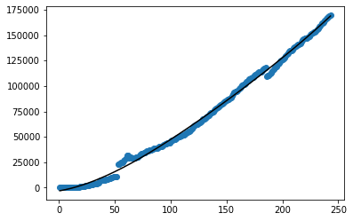

```python
df = pd.read_csv('Covid-19.csv').fillna(0)
ndf= df.loc[(df['location'] == 'Ecuador') & (df['total_cases'] != 0)]
ndf1=ndf[['date','total_cases','total_deaths']]
x=np.arange(1,len(ndf1)+1,1, dtype='float')
y=np.array(ndf1.values[:,1], dtype='float')
z=np.array(ndf1.values[:,2],dtype='float')
fun1 = np.poly1d(np.polyfit(x, y, 4))
print(fun1)
plt.scatter(x, y)
plt.plot(x, fun1(x), c='black')
plt.show()
```

```
           4           3         2
2.792e-05 x - 0.01695 x + 4.623 x + 185.4 x - 3227
```

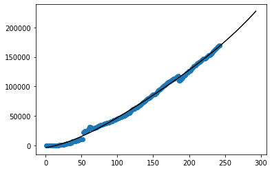

```python
fun1 = np.poly1d(np.polyfit(x, y, 4))
print(fun1)
plt.scatter(x, y)
x1=np.arange(1,len(ndf1)+51,1, dtype='float')
plt.plot(x1, fun1(x1), c='black')
plt.show()
```

### Numero de Muertes

```
           4            3          2
-2.45e-06 x + 0.001535 x - 0.1634 x + 43.97 x - 716.3
```

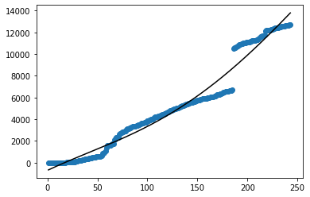

```python
fun1 = np.poly1d(np.polyfit(x, y1, 4))
print(fun1)
plt.scatter(x, z)
plt.plot(x, fun1(x), c='black')
plt.show()
```

## Criterio personal (politico, economico y social de la situacion)

### Político

Se debe tener presente las medidas de prevención contra el virus ya que así podremos evitar que se aumente los contagios en el país.

### Económico

Este virus ha afectado a varias empresas ya que por evitar el contagio deben cerrarse la cual, tambien en algunas empresas despedían a empleados por lo que estaba en stop el negocio y no generaban ingresos. El país presente grandes desequilibrios en dinero ya que por las restricciones se tiene una diferente manera de trabajar

### Social

Mediante este análisis podemos ver en qué estado se encuentra el país por lo que debemos seguir con las medidas de prevención contra el COVID-19 para así evitar contagios ya que en las gráficas se puede observar altos índices de casos nuevos y de numerosas muertes en el Ecuador.

# Referencias

- https://www.researchgate.net/publication/340092755_Infeccion_del_Covid-19_en_Colombia_Una_comparacion_de_modelos_logisticos_y_exponenciales_aplicados_a_la_infeccion_por_el_virus_en_Colombia
- https://www.aprendemachinelearning.com/regresion-lineal-en-espanol-con-python/